## MGOC15 - Introductory Business Data Analytics

# Data Assignment 2 (6 Points)

**Topics Tested:** Data Visualization, Filtering & Boolean Operations, Data Merging, Groupby  
You may work in teams of two (or individually) but you must each submit your assignment separately and also mention your partner's name so that your work does not seem plagiarized.

### Hospital Bed Analysis

One of the critical issues during the COVID-19 pandemic was the management of hospital beds across Canada. In this question, you will perform the first-step analysis in better understanding the different types of beds and how they are distributed in Canada.

The two files *hospital_data_final.csv* and *icu_data.csv* have the overall and ICU bed information in Canada (up to early 2020), as provided directly by the **Canadian Institute for Health Information**. Since the ICU beds are typically managed by a different department in the hospital (emergency administration), there is a different dataset for this.

The column information is as follows:

1. *Province:* The province of the hospital.
2. *Health region:* The health region in the province the hospital is associated with. Each province has its own regional divisions.
3. *Hospital:* The hospital name.
4. *Type of hospital:* A string of letters associated with each hospital, where:  
   4.1. **G:** General  
   4.2. **S-Ped**: Specialty — Pediatric  
   4.3. **C**: Cancer Treatment  
   4.4. **S-Psy**: Specialty — Psychiatric  
   4.5. **S-Oth**: Specialty — Other  
   4.6. **R**: Rehabilitation  
   4.7. **E**: Extended Care/Chronic  
   4.8. **n/a**: No data was available.
5. *Remaining columns:* Number of beds of each type. Empty indicates the hospital has no beds of that specialty.

In the *icu_data.csv*, the columns are the hospital name and the number of ICU beds. Note that the list of hospitals in the two datasets may not match perfectly --- this is because some of the hospitals in *hospital_data_final.csv* do not contain ICU beds and their names are not present in the ICU dataset.

Answer the following managerial questions below to draw important insights on how beds are distributed in Canada. The answer to every single question must contain an explanation - simply writing the code will not suffice. The explanation can be written as a comment or a markdown cell.

**Note:** Before answering the questions, please go to to the Jupyter's menu and execute "Kernel", "Restart & Run all." This will ensure that the notebook and modules are appropriately loaded.

*This assignment is worth 6 points*

### Loading Python modules

We start by first importing packages and modules needed for our analysis

Student 1: Arailym Mussilim, 1005693108 Student 2: Magen Chen, 1005951043

```python
import pandas as pd               # for data manipulation
import numpy as np                # for stats and numerical analysis
import matplotlib.pyplot as plt   # for plotting and data visualization
```

### Retrieving data

Let us begin by reading and understanding the two datasets

```python
# Read the hospital_data_final.csv file below
dfRest = pd.read_csv('hospital_data_final.csv')

# Read the icu_data.csv file below
dfICU = pd.read_csv('icu_data.csv')

#Display the head of the two files below
print(dfRest.head(5))
```

```
  Province      Health region                      Hospital Type of hospital  \
0       ON  Central East LHIN    Scarborough Health Network                G
1       ON       Central LHIN         Humber River Hospital                G
2       ON       Central LHIN              Mackenzie Health                G
3       ON       Central LHIN  Markham Stouffville Hospital                G
4       ON       Central LHIN   North York General Hospital                G

  Teaching status  Obstetrics  Pediatrics  Mental Health and Addictions  \
0    Non-Teaching          50          26                            92
1    Non-Teaching          25          14                            64
2    Non-Teaching          14           6                            25
3    Non-Teaching          29           5                            33
4    Non-Teaching          28          12                            50

   Rehabilitation  Long-Term Care  Other Acute
0              20              33          482
1              18               0          466
2              23              74          259
3              31              10          188
4               0               0          320
```

```python
#Print the ICU Dataset First Five Rows
print(dfICU.head(5))
```

```
                       Hospital  Intensive Care
0    Scarborough Health Network              62
1         Humber River Hospital              41
2              Mackenzie Health              30
3  Markham Stouffville Hospital              10
4   North York General Hospital              21
```

```python
#Check the length of the two files below:

print(len(dfRest),len(dfICU))
```

```
628 205
```

### Question 1: (1 point)

Merge the two dataframes dfRest and dfICU into a new dataframe called dfHospitalFull below. It is important to identify the right type of merge. Remember, some hospitals do not have any ICU beds and therefore their names are present in the dfRest dataframe but not in dfICU.

```python
dfHospitalFull = pd.merge(dfRest,dfICU,how="outer",on="Hospital")
```

```python
#Don't forget to run this code after merging. When there is a missing value, this will fill it with 0.
#We will discuss this in detail in a later lecture.
dfHospitalFull = dfHospitalFull.fillna(0)
```

### Question 2 (1.5 points)

We first want to gauge how provinces differ in terms of their health resources. Consider the two provinces of Alberta and British Columbia. Their populations are almost identical. Now, answer the following questions:

a) Which of these two provinces have more ICU beds in total? To answer this question, you must first filter the information corresponding to Alberta into a new dataframe called dfAB and similarly, filter the information for British Columbia into dfBC.

b) Display the median number of ICU beds in both these provinces.

c) Is there a discrepancy between the answers for Questions 2a and 2b? If so, what do you think is the reason.

You can ignore any difference in their populations for this question.

```python
#Answer 2a
dfAB = dfHospitalFull[dfHospitalFull['Province']=='AB']
print(dfAB['Intensive Care'].sum())
dfBC = dfHospitalFull[dfHospitalFull['Province']=='BC']
print(dfBC['Intensive Care'].sum())
#answer: BC has more ICU beds in total than AB
```

```
400.0
478.0
```

```python
#Answer 2b
dfABmedian = dfAB['Intensive Care'].median()
dfBCmedian = dfBC['Intensive Care'].median()
print("The median number of ICU beds in AB is ", dfABmedian)
print("The median number of ICU beds in BC is ", dfBCmedian)
```

```
The median number of ICU beds in AB is  0.0
The median number of ICU beds in BC is  0.0
```

### Question 3 (1.5 points)

Recently there is a big concern that Canadian hospitals are overflowing with sick children and there aren't enough beds. With this in mind, answer the following questions:

a) What are the top 3 provinces in Canada that have the most pediatric beds per hospital, *on average*?

b) Visualize the information from Question 3a) using a suitable plot. In other words, your plot must only show the names of the top 3 provinces and the number of pediatric beds per hospitals. Don't forget to label your axes if appropriate.

**Hint**: Once you do a groupby(), save the outcome to a new dataframe, sort in descending order of pediatric beds, and use head(3) to extract the top 3. You may use other methods as well.

```
Province
QC    20.000000
ON     3.535211
NB     3.240000
Name: Pediatrics, dtype: float64
```

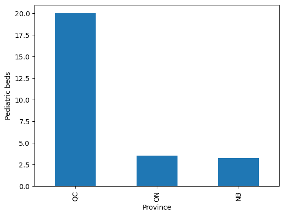

```python
dfGroupby = dfHospitalFull.groupby('Province')['Pediatrics'].mean()
dfgroup = (dfGroupby.sort_values(ascending=False)).head(3)
print(dfgroup)
#3a answer: QC, ON, NB

dfgroup.plot.bar()
plt.ylabel("Pediatric beds")
```

### Question 4 (1.5 points)

a) Plot a histogram to better understand the distribution of ICU beds in hospitals all across Canada.

b) In this question we will start to understand the correlation between ICU beds and obstetrics beds in hospitals. First, create a new dataframe called dfBest that contains only the information from those hospitals with at least 15 ICU Beds. Now calculate the average number of obstetrics beds for the hospitals in dfBest.

How does this number compare to the overall average number of obstetrics beds. What does tell you about the correlation between these two variables?

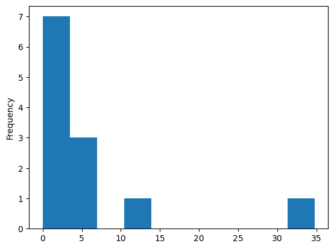

```python
dfHist = dfHospitalFull.groupby('Province')['Intensive Care'].mean()
dfHist.plot.hist()
```

```python
dfBest = dfHospitalFull[dfHospitalFull['Intensive Care']>=15]
averageHighICU = dfBest['Obstetrics'].mean()
print("the average number of obstetrics beds for the hospitals in dfBest is ", averageHighICU)

averageAll = dfHospitalFull['Obstetrics'].mean()
print("the overall average number of obstetrics beds is ", averageAll)
```

```
the average number of obstetrics beds for the hospitals in dfBest is  32.72826086956522
the overall average number of obstetrics beds is  6.952229299363057
```

If you compare the two average numbers, it is clear that hospitals with more ICU beds are also better equipped in Obstetrics.

### Question 5 (0.5 points + 0.5 bonus)

This is an open-ended and essay-type question. No data analytics or code is required. The purpose of this question is to test your critical thinking.

ChatGPT has recently taken the world by storm and many pundits have predicted that it will totally revolutionize our education system, and perhaps even render it obsolete. After all, if students can learn directly from ChatGPT in a personalized fashion, maybe there is no need for universities or instructors. However, your MGOC15 instructor is fully convinced and historical evidence suggests that educational institutions are more likely to integrate this into their everyday operations (remember how robots were supposed to replace humans?).

**Question:** Predict two ways in which large language models like ChatGPT will change university education. Explain your prediction will details.

You may read articles on the topic if you like (e.g., see below) but your actual answer must reflect your original thinking. Answers that are plagiarized off the Internet or ChatGPT itself will not receive any points. No code is required for this question.

https://www.theglobeandmail.com/canada/article-chatgpt-education-ai-technology/

**The two teams with the most original answers will be awarded a bonus of 0.5 points**

[figure not shown]

Professors and teaching faculty members can integrate ChapGPT into every day lectures. For example, when there is a new topic, students can collect general information on the topic using ChaptGPT and then discuss the implications and real-life applications in class. ChatGPT should only be used for the sake of information gathering and as a starting point for in-class discussions. Another specific way for integration would be to ask ChatGPT to come up with short paragraphs on various topics and students can be asked to create a business idea or a product idea using the information provided by ChatGPT. Humans still hold advantage over AI when it comes to ideation. So we can use ChapGPT to our advantage by using it to facilitate our ideation skill improvement.